# Rapport Travail Pratique N°1

Emma BRAZ DA COSTA-RAMOS (BRAE21560400) Gautier BRÈRE (BRIG01040400) Edward CARAMANOS (CARE17080300) Mariama CIRÉ CAMARA (CAMM06609200) Yoann CORGNET (CORY14010400)

2025-02-10

## I- Importation et nettoyage des données

Ce dataset contient les métadonnées de plus de 700 000 films répertoriés dans l’ensemble de données TMDB. Il est mis à jour quotidiennement pour garantir la mise à jour de l’ensemble de données sur les films. Les points de données comprennent les acteurs, l’équipe, les mots-clés de l’intrigue, le budget, les revenus, les affiches, les dates de sortie, les langues, les sociétés de production, les pays, le nombre de votes TMDB et les moyennes des votes, les critiques, les recommandations.

**Description des variables**

- id : Identifiant unique pour chaque film.
- title : Titre du film.
- genres : Genres du film, combinés dans une seule chaîne de caractères (ex : Action-Comedy).
- original_language : Langue originale du film.
- overview : Résumé ou description du film.
- popularity : Score de popularité du film.
- production_companies : Compagnies de production associées au film, listées dans une chaîne de caractères.
- release_date : Date de sortie du film.
- budget : Budget du film en dollars.
- revenue : Revenu généré par le film en dollars.
- runtime : Durée du film en minutes.
- status : Statut du film (ex : Released).
- tagline : Slogan du film.
- vote_average : Moyenne des votes pour le film.
- vote_count : Nombre total de votes reçus par le film.
- credits : Principaux acteurs et membres de l’équipe du film.
- keywords : Mots-clés associés au film, listés dans une chaîne de caractères.
- poster_path : Chemin vers l’image de l’affiche du film.
- backdrop_path : Chemin vers l’image de fond du film.
- recommendations : Identifiants de films recommandés basés sur ce film, listés dans une chaîne de caractères.

### A- Importation des données

```r
movies <- read.csv("data/movies.csv")
```

Le dataset compte 722317 entrées pour 20 variables.

### B- Supression des variables non pertinentes

Voici le résumé des variables du dataset:

```r
skim(movies)
```

Data summary

| Name | movies |
| --- | --- |
| Number of rows | 722317 |
| Number of columns | 20 |
| _______________________ |  |
| Column type frequency: |  |
| character | 13 |
| numeric | 7 |
| ________________________ |  |
| Group variables | None |

**Variable type: character**

| skim_variable | n_missing | complete_rate | min | max | empty | n_unique | whitespace |
| --- | --- | --- | --- | --- | --- | --- | --- |
| title | 0 | 1 | 0 | 234 | 4 | 575321 | 0 |
| genres | 0 | 1 | 0 | 129 | 210317 | 11050 | 0 |
| original_language | 0 | 1 | 2 | 2 | 0 | 167 | 0 |
| overview | 0 | 1 | 0 | 999 | 118243 | 541884 | 6 |
| production_companies | 0 | 1 | 0 | 679 | 384926 | 147600 | 0 |
| release_date | 0 | 1 | 0 | 10 | 51549 | 41474 | 0 |
| status | 0 | 1 | 7 | 15 | 0 | 6 | 0 |
| tagline | 0 | 1 | 0 | 284 | 613841 | 95910 | 4 |
| credits | 0 | 1 | 0 | 7172 | 224714 | 423217 | 0 |
| keywords | 0 | 1 | 0 | 1258 | 511678 | 119803 | 0 |
| poster_path | 0 | 1 | 0 | 32 | 184493 | 483219 | 0 |
| backdrop_path | 0 | 1 | 0 | 32 | 499106 | 197370 | 0 |
| recommendations | 0 | 1 | 0 | 156 | 686301 | 32104 | 0 |

**Variable type: numeric**

| skim_variable | n_missing | complete_rate | mean | sd | p0 | p25 | p50 | p75 | p100 | hist |
| --- | --- | --- | --- | --- | --- | --- | --- | --- | --- | --- |
| id | 0 | 1.00 | 526920.12 | 253200.15 | 2 | 328914.0 | 533351.0 | 737872.0 | 968161 | ▃▇▇▇▇ |
| popularity | 0 | 1.00 | 1.92 | 23.69 | 0 | 0.6 | 0.6 | 1.3 | 8764 | ▇▁▁▁▁ |
| budget | 0 | 1.00 | 404345.28 | 8242867.85 | 0 | 0.0 | 0.0 | 0.0 | 5000000000 | ▇▁▁▁▁ |
| revenue | 0 | 1.00 | 1007747.33 | 20483206.23 | -12 | 0.0 | 0.0 | 0.0 | 2920357254 | ▇▁▁▁▁ |
| runtime | 34335 | 0.95 | 199.09 | 85842.57 | 0 | 5.0 | 50.0 | 90.0 | 50505050 | ▇▁▁▁▁ |
| vote_average | 0 | 1.00 | 2.45 | 3.18 | 0 | 0.0 | 0.0 | 5.6 | 10 | ▇▁▂▂▁ |
| vote_count | 0 | 1.00 | 28.48 | 396.58 | 0 | 0.0 | 0.0 | 2.0 | 34857 | ▇▁▁▁▁ |

Pour notre analyse et pour réduire la taille du dataset, nous supprimerons les variables que nous n’utiliserons pas pour notre analyse :

```r
clean_movies <- select(movies, -id, -overview, -tagline, -credits, -keywords, -poster_path, -backdrop_path, -recommendations)
head(clean_movies)
```

```
##                              title                           genres
## 1                Meg 2: The Trench    Action-Science Fiction-Horror
## 2              The Pope's Exorcist          Horror-Mystery-Thriller
## 3             Deadpool & Wolverine    Action-Comedy-Science Fiction
## 4 Transformers: Rise of the Beasts Action-Adventure-Science Fiction
## 5                   Dune: Part Two        Science Fiction-Adventure
## 6            Venom: The Last Dance Science Fiction-Action-Adventure
##   original_language popularity
## 1                en   8763.998
## 2                en   5953.227
## 3                en   5410.496
## 4                en   5409.104
## 5                en   4742.163
## 6                en   4674.885
##                                                                                                             production_companies
## 1 Apelles Entertainment-Warner Bros. Pictures-di Bonaventura Pictures-CMC Pictures-Gravity Pictures-China Film Group Corporation
## 2                                         Screen Gems-2.0 Entertainment-Jesus & Mary-Worldwide Katz-Loyola Productions-FFILME.RO
## 3             Marvel Studios-Maximum Effort-21 Laps Entertainment-20th Century Studios-Kevin Feige Productions-TSG Entertainment
## 4            Skydance-Paramount-di Bonaventura Pictures-Bay Films-New Republic Pictures-Tom DeSanto/Don Murphy Production-Hasbro
## 5                                                                                                             Legendary Pictures
## 6                         Columbia Pictures-Pascal Pictures-Matt Tolmach Productions-Hutch Parker Entertainment-Arad Productions
##   release_date   budget    revenue runtime   status vote_average vote_count
## 1   2023-08-02 1.29e+08  352056482     116 Released        7.079       1365
## 2   2023-04-05 1.80e+07   65675816     103 Released        7.433        545
## 3   2024-07-24 2.00e+08 1326387384     128 Released        7.765       3749
## 4   2023-06-06 2.00e+08  407045464     127 Released        7.340       1007
## 5   2024-02-27 1.90e+08  683813734     167 Released        8.300       2770
## 6   2024-10-22 1.20e+08  310000000     109 Released        6.522        603
```

### C- Nettoyage des variables

- **Variable `release_date` :**

Regardons la distribution des dates de sorties :

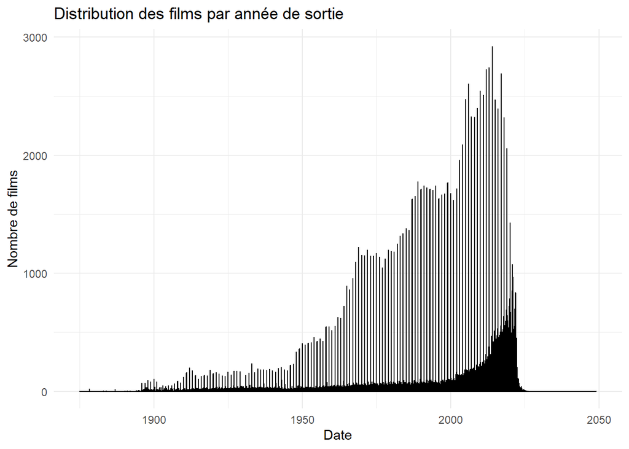

```r
clean_movies$release_date <- as.Date(clean_movies$release_date, format="%Y-%m-%d")

ggplot(clean_movies, aes(x = release_date)) +
  geom_histogram(binwidth = 5, fill="steelblue", color="black") +
  labs(title="Distribution des films par année de sortie", x="Date", y="Nombre de films") +
  theme_minimal()
```

On peut observer deux choses :  
1- Les films ont tendance à sortir à des dates précises durant l’année, nous nous retrouvons donc avec des pics.  
Pour notre analyse, nous regarderons donc l’année, le mois et la décennie de sortie, et non la date exacte:

```r
# Suppression des dates maquantes
clean_movies <- clean_movies %>% filter(!is.na(release_date))
# Ajout des variables
clean_movies <- clean_movies %>%
  mutate(
    release_year = as.numeric(format(release_date, "%Y")),
    release_mounth = as.numeric(format(release_date, "%m")),
    release_decate = as.numeric(format(release_date, "%Y")) %/% 10 * 10
  )

head(clean_movies %>% select(title, release_date, release_year, release_mounth, release_decate))
```

```
##                              title release_date release_year release_mounth
## 1                Meg 2: The Trench   2023-08-02         2023              8
## 2              The Pope's Exorcist   2023-04-05         2023              4
## 3             Deadpool & Wolverine   2024-07-24         2024              7
## 4 Transformers: Rise of the Beasts   2023-06-06         2023              6
## 5                   Dune: Part Two   2024-02-27         2024              2
## 6            Venom: The Last Dance   2024-10-22         2024             10
##   release_decate
## 1           2020
## 2           2020
## 3           2020
## 4           2020
## 5           2020
## 6           2020
```

2- Nous observons que certains films sont sortis après 2025, regardons desquels il s’agit :

```r
clean_movies %>% filter(release_date > "2025-01-22") %>% select(title, status, release_date) %>% head()
```

```
##                                       title          status release_date
## 1 Mission: Impossible - The Final Reckoning Post Production   2025-05-21
## 2                         A Minecraft Movie Post Production   2025-04-02
## 3                            Fast X: Part 2         Planned   2025-04-04
## 4           The Fantastic Four: First Steps   In Production   2025-07-23
## 5                                  Avatar 4   In Production   2026-12-16
## 6                                  Avatar 5   In Production   2028-12-20
```

Ce sont donc des films qui ne sont pas encore sortis et dont la date est une prévision.  
Pour notre analyse, nous nous concentrerons uniquement sur les films sortis:

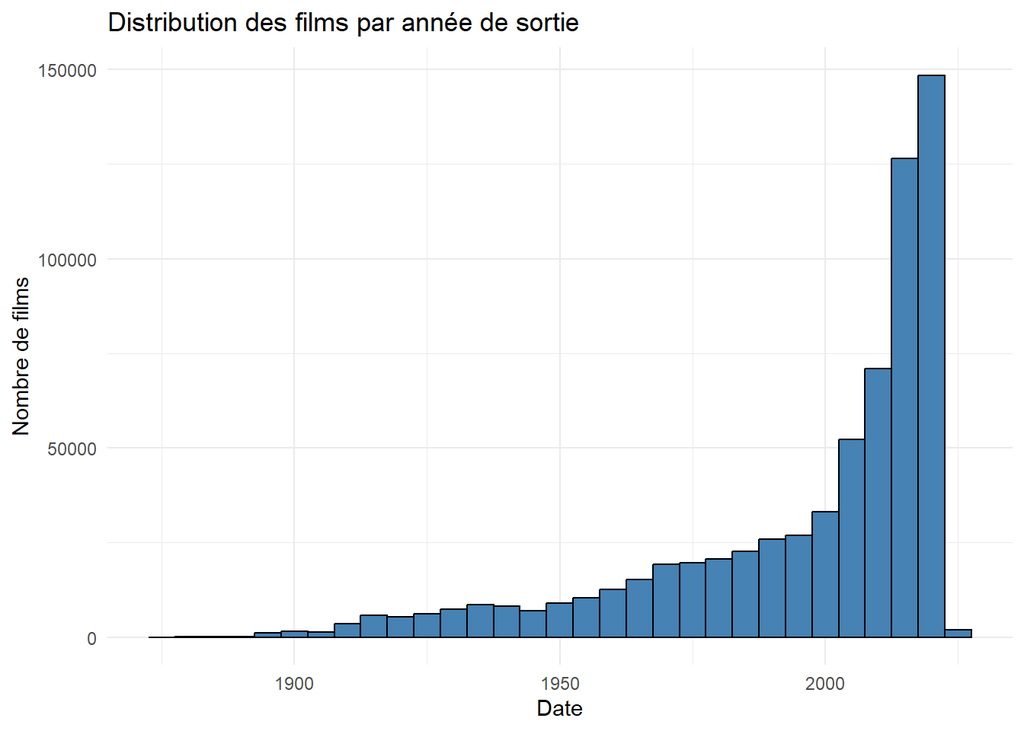

```r
clean_movies <- clean_movies %>% filter(status == "Released")

ggplot(clean_movies, aes(x = release_year)) +
  geom_histogram(binwidth = 5, fill="steelblue", color="black") +
  labs(title="Distribution des films par année de sortie", x="Date", y="Nombre de films") +
  theme_minimal()
```

- **Variable `runtime` :**

Après une observation des durées de films, nous remarquons plusieurs choses intéressantes :

```r
clean_movies %>%
  filter(!is.na(runtime)) %>%
  arrange(desc(runtime)) %>%
  head(10) %>%
  select(title, runtime)
```

```
##                         title runtime
## 1                   Logistics   51420
## 2                    Ambiancé   43200
## 3        Modern Times Forever   14400
## 4  Svalbard minutt for minutt   13319
## 5                   Cinématon   12480
## 6                   Cinématon   12480
## 7                Beijing 2003    9000
## 8     Untitled #125 (Hickory)    7200
## 9                 Matrjoschka    5700
## 10               #ALLMYMOVIES    4320
```

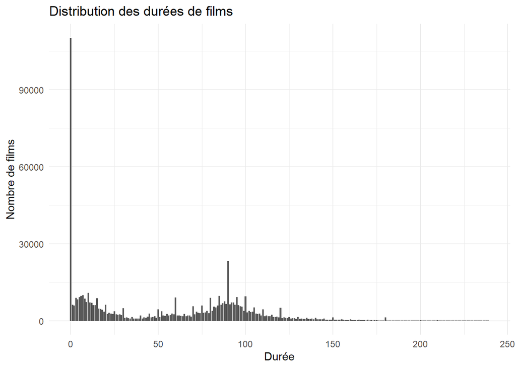

```r
clean_movies = clean_movies %>%
  filter(runtime < 240) # Limitons-nous à des films de moins de 4h

ggplot(clean_movies, aes(runtime)) +
  geom_bar() +
  labs(title="Distribution des durées de films", x="Durée", y="Nombre de films") +
  theme_minimal()
```

L’histogramme de la durée des films de moins de 4h nous permet d’obtenir plusieurs informations :  
1. On observe une distinction entre les courts métrages (10 min en moyenne) et les longs métrages (1h30 en moyenne).  
2. Il existe beaucoup de films dont la durée est de zéro: 110196 au total (soit 17.21 %).

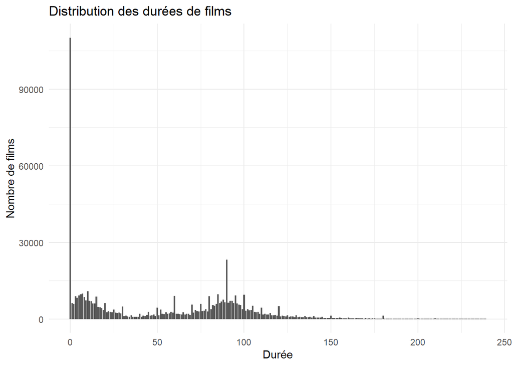

```r
clean_movies <- clean_movies %>% filter(!is.na(runtime) | runtime > 0)

ggplot(clean_movies, aes(runtime)) +
  geom_bar() +
  labs(title="Distribution des durées de films", x="Durée", y="Nombre de films") +
  theme_minimal()
```

- **Variable `genres` :**

Le genre des films est stocké sous la forme “genre_principale[-genre_secondaire]…”, ce qui fait que nous nous retrouvons avec un total de 11050 genres.

Nous allons séparer ces genres, puis compter le nombre de films par genre.

```r
clean_movies <- clean_movies %>%
  separate_rows(genres, sep = "-")

head(clean_movies%>% select(title,genres))
```

```
## # A tibble: 6 × 2
##   title               genres
##   <chr>               <chr>
## 1 Meg 2: The Trench   Action
## 2 Meg 2: The Trench   Science Fiction
## 3 Meg 2: The Trench   Horror
## 4 The Pope's Exorcist Horror
## 5 The Pope's Exorcist Mystery
## 6 The Pope's Exorcist Thriller
```

Nous nous retrouvons donc avec 20 genres.

Top 3 des genres principaux :

```r
clean_movies %>%
  filter(!is.na(genres)) %>%
  count(genres) %>%
  arrange(desc(n)) %>%
  head(n = 3)
```

```
## # A tibble: 3 × 2
##   genres             n
##   <chr>          <int>
## 1 "Drama"       167483
## 2 ""            158555
## 3 "Documentary" 108934
```

- **Variables `vote_count` et `vote_average` :**

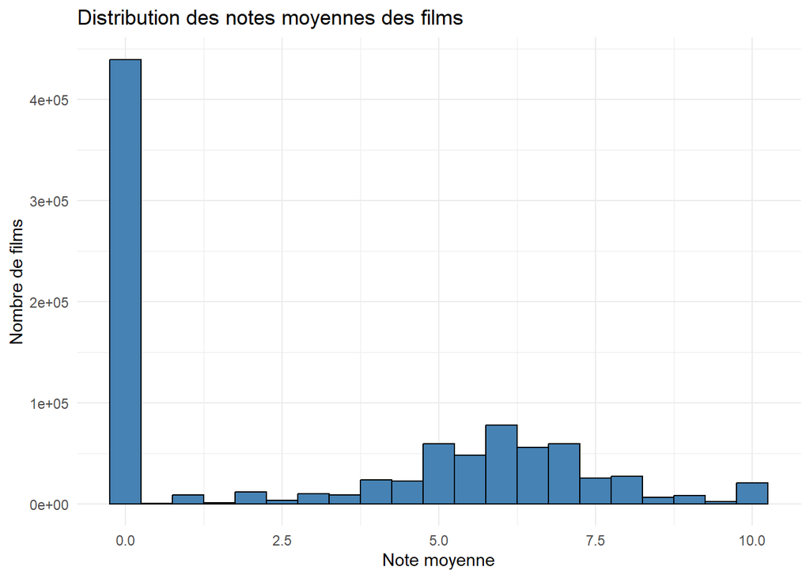

```r
ggplot(clean_movies, aes(x = vote_average)) +
  geom_histogram(binwidth = 0.5, fill="steelblue", color="black") +
  labs(
    title = "Distribution des notes moyennes des films",
     x = "Note moyenne",
     y = "Nombre de films"
  ) +
  theme_minimal()
```

Nous observons que beaucoup de notes sont à zéro, cela peut être dû à deux choses :  
1- La note du film est de 0  
2- Le nombre de votes est de zéro, la moyenne est donc automatiquement à zéro. Cela représente 439154 films sur les 439753 qui ont une note de zéro, soit 99.86 %.

Nous ne tiendrons donc pas compte de ces films :

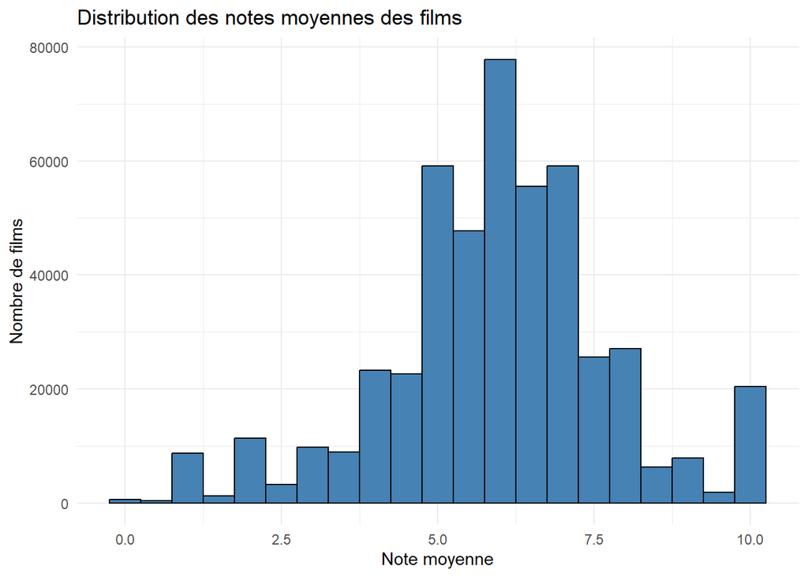

```r
clean_movies = clean_movies %>% filter(vote_count != 0)

ggplot(clean_movies, aes(x = vote_average)) +
  geom_histogram(binwidth = 0.5, fill="steelblue", color="black") +
  labs(
    title = "Distribution des notes moyennes des films",
     x = "Note moyenne",
     y = "Nombre de films"
  ) +
  theme_minimal()
```

### D- Rééchantillonnage

Après nettoyage, nous nous retrouvons avec un un dataset de 478134 films.  
Afin que le traitement des données ne soit pas trop lourd, ni prennent trop de temps, nous prendrons un échantillon de 100 000 films.

```r
set.seed(42)
clean_movies <- sample_n(clean_movies, size = 100000)
```

Voici donc le résumé des variables du dataset après nettoyage :

```r
skim(clean_movies)
```

Data summary

| Name | clean_movies |
| --- | --- |
| Number of rows | 100000 |
| Number of columns | 15 |
| _______________________ |  |
| Column type frequency: |  |
| character | 5 |
| Date | 1 |
| numeric | 9 |
| ________________________ |  |
| Group variables | None |

**Variable type: character**

| skim_variable | n_missing | complete_rate | min | max | empty | n_unique | whitespace |
| --- | --- | --- | --- | --- | --- | --- | --- |
| title | 0 | 1 | 1 | 136 | 0 | 80034 | 0 |
| genres | 0 | 1 | 0 | 15 | 7462 | 20 | 0 |
| original_language | 0 | 1 | 2 | 2 | 0 | 119 | 0 |
| production_companies | 0 | 1 | 0 | 679 | 28880 | 40033 | 0 |
| status | 0 | 1 | 8 | 8 | 0 | 1 | 0 |

**Variable type: Date**

| skim_variable | n_missing | complete_rate | min | max | median | n_unique |
| --- | --- | --- | --- | --- | --- | --- |
| release_date | 0 | 1 | 1878-06-14 | 2024-10-22 | 2008-01-01 | 24224 |

**Variable type: numeric**

| skim_variable | n_missing | complete_rate | mean | sd | p0 | p25 | p50 | p75 | p100 | hist |
| --- | --- | --- | --- | --- | --- | --- | --- | --- | --- | --- |
| popularity | 0 | 1 | 4.98 | 56.82 | 0.08 | 0.71 | 1.4 | 3.28 | 8764 | ▇▁▁▁▁ |
| budget | 0 | 1 | 1664453.57 | 11696745.45 | 0.00 | 0.00 | 0.0 | 0.00 | 379000000 | ▇▁▁▁▁ |
| revenue | 0 | 1 | 4421675.50 | 44210802.93 | 0.00 | 0.00 | 0.0 | 0.00 | 2920357254 | ▇▁▁▁▁ |
| runtime | 0 | 1 | 74.93 | 42.93 | 0.00 | 48.00 | 88.0 | 100.00 | 239 | ▅▇▅▁▁ |
| vote_average | 0 | 1 | 5.95 | 1.79 | 0.00 | 5.00 | 6.0 | 7.00 | 10 | ▁▂▇▇▂ |
| vote_count | 0 | 1 | 114.75 | 838.66 | 1.00 | 1.00 | 4.0 | 16.00 | 34857 | ▇▁▁▁▁ |
| release_year | 0 | 1 | 1997.11 | 25.85 | 1878.00 | 1985.00 | 2008.0 | 2016.00 | 2024 | ▁▁▁▂▇ |
| release_mounth | 0 | 1 | 6.36 | 3.70 | 1.00 | 3.00 | 6.0 | 10.00 | 12 | ▇▃▃▅▇ |
| release_decate | 0 | 1 | 1992.54 | 25.96 | 1870.00 | 1980.00 | 2000.0 | 2010.00 | 2020 | ▁▁▂▃▇ |

Pour terminer, nous répartissons notre jeu de données entre l’entraînement et les tests, avec une proportion de 80% :

```r
train_test_split <- initial_split(clean_movies, prop = 0.8)

train_movies <- training(train_test_split)
test_movies <- testing(train_test_split)
```

## II- Visualisation / analyse aprofondie

**-Visualisation de la repartion des genres de films dans nos données**

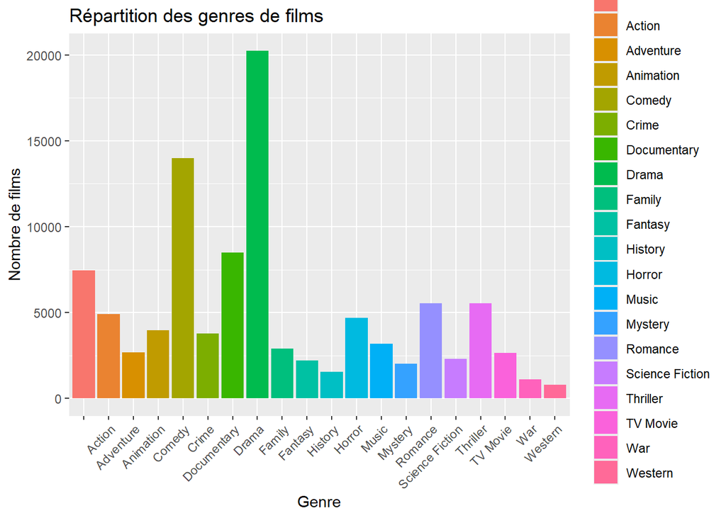

```r
# Visualisons la repartion du premier genre des films
gender_movie<- clean_movies%>%
  group_by(genres)%>%
  filter(!is.na(genres)) %>%
  summarise(count=n(),.groups = 'drop')
ggplot(gender_movie, aes(x = genres, y = count, fill = genres)) +
  geom_bar(stat = "identity") +
  theme(axis.text.x = element_text(angle = 45, hjust = 1)) +
  labs(title = "Répartition des genres de films", x = "Genre", y = "Nombre de films")
```

En visualisant les répartitions, nous remarquons que les films de genre ‘DRAME’ sont majoritairement dominants, en suite les Comedies, documentaires, Romance, Thriller..

**- Visualisation du revenu moyen généré par genre de film**

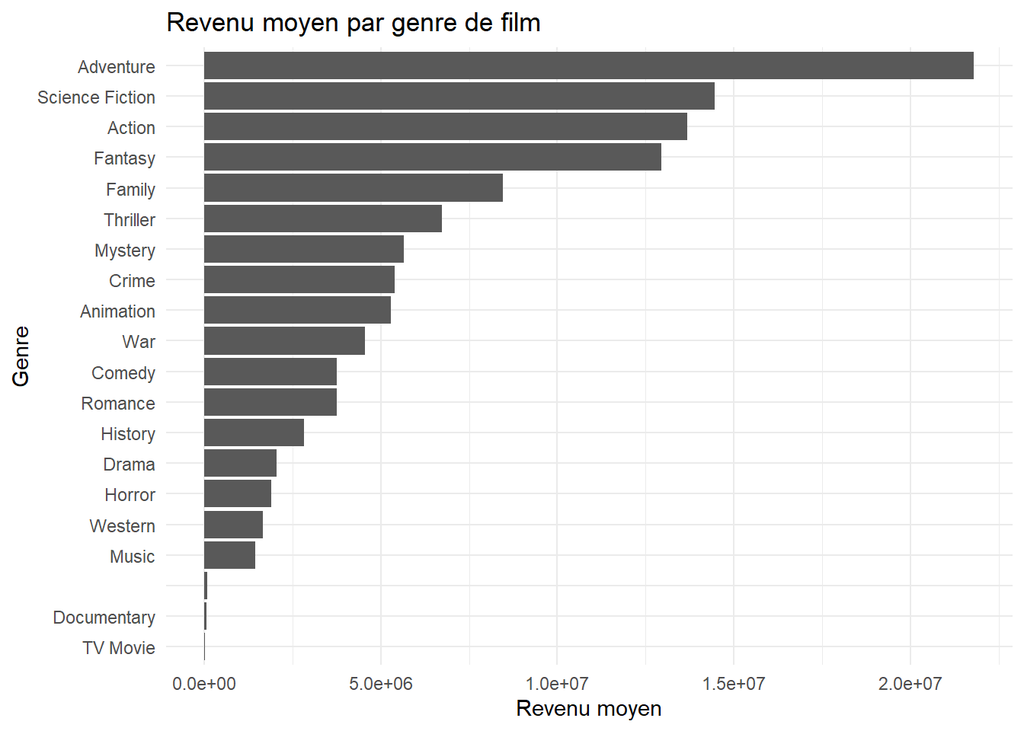

```r
genre_revenue<-clean_movies%>%
  group_by(genres)%>%
  summarise(average_revenue=mean(revenue, is.na=TRUE, .groups='drop'))
ggplot(genre_revenue, aes(x = reorder(genres, average_revenue), y = average_revenue)) +
  geom_bar(stat = "identity") +
  coord_flip() +
  labs(title = "Revenu moyen par genre de film",
       x = "Genre",
       y = "Revenu moyen") +
  theme_minimal()
```

D’après cette visualisation, les films d’aventure sont plus rentables tant dis que les films documentaires et Emission TV ne génèrent presque pas de revenu. Cela peut s’expliquer par le fait que ces genres ne soient presque pas diffusés en salle et moins sur les plateformes de distribution, et aussi ils visent un public minoritaire.

**- Voyons l’evolution des genres de film au fil des décennies**

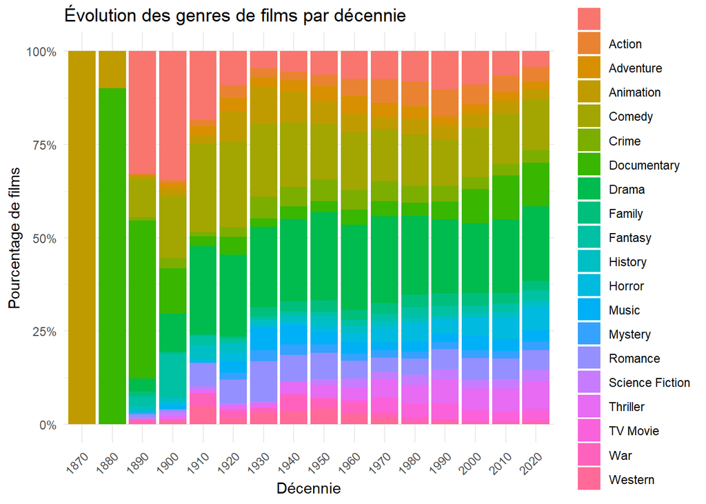

```r
# graphique interactif en barres empilées pour voir l'evolution des tendances
plot_movies<-clean_movies%>%
  count(release_decate, genres)
gg<-ggplot(plot_movies, aes(x = factor(release_decate), y = n, fill = genres)) +
  geom_bar(stat = "identity", position = "fill") +
  scale_y_continuous(labels = scales::percent_format()) +
  labs(title = "Évolution des genres de films par décennie",
       x = "Décennie",
       y = "Pourcentage de films",
       fill = "Genre") +
  theme_minimal() +
  theme(axis.text.x = element_text(angle = 45, hjust = 1))
gg
```

```r
#print(ggplotly(gg))
```

**-Visualisons la Spécialisation des compagnies par genre**

```r
top_companies <- clean_movies %>%
  count(production_companies, sort = TRUE) %>%
  top_n(15)
```

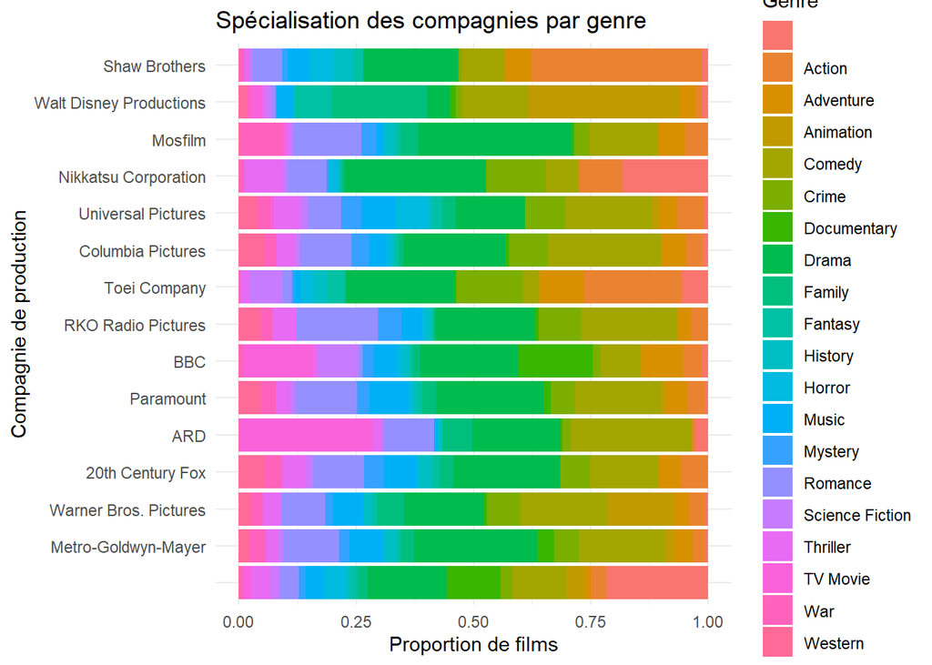

```r
company_genre_distribution <- clean_movies %>%
  filter(production_companies %in% top_companies$production_companies) %>%
  group_by(production_companies, genres) %>%
  summarise(count = n(), .groups = 'drop')

ggplot(company_genre_distribution, aes(x = reorder(production_companies, -count), y = count, fill = genres)) +
  geom_bar(stat = "identity", position = "fill") +
  coord_flip() +
  labs(title = "Spécialisation des compagnies par genre",
       x = "Compagnie de production",
       y = "Proportion de films",
       fill = "Genre") +
  theme_minimal()
```

**-Visualisons la Rentabilité des films**

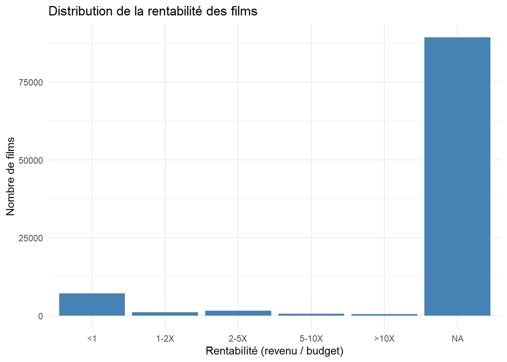

```r
rentability_thresholds <- c(1, 2, 5, 10)
rentability_categories <- cut(clean_movies$revenue / clean_movies$budget,
                              breaks = c(-Inf, 1, 2, 5, 10, Inf),
                              labels = c("<1", "1-2X", "2-5X", "5-10X", ">10X"),
                              right = FALSE)

ggplot(data.frame(Rentabilité = rentability_categories), aes(x = Rentabilité)) +
  geom_bar(fill = "steelblue") +
  labs(title = "Distribution de la rentabilité des films",
       x = "Rentabilité (revenu / budget)",
       y = "Nombre de films") +
  theme_minimal()
```

On observe que une partie non négligeable des films ne sont pas rentable.

**- Voyons l’evolution de la rentabilité**

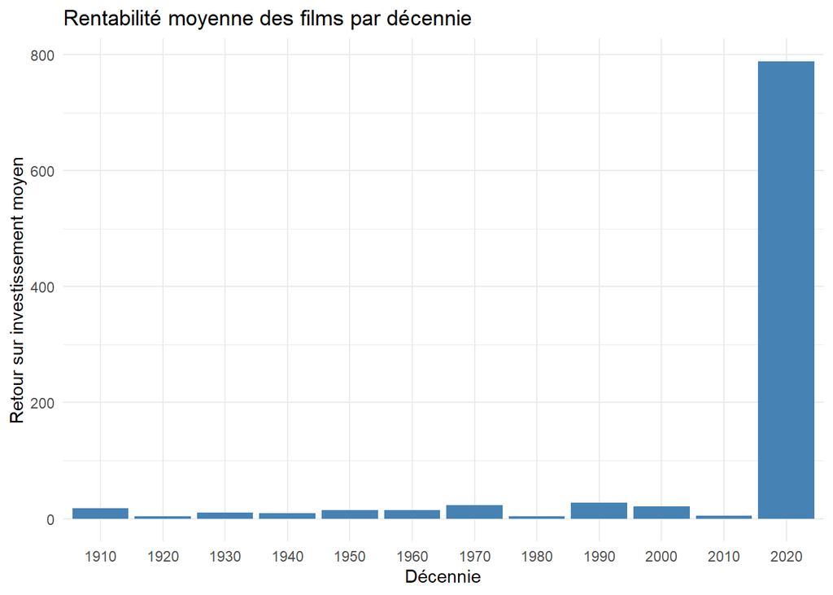

```r
clean_movies <- clean_movies %>%
  mutate(release_decade = floor(release_year / 10) * 10)

clean_movies <- clean_movies %>%
  filter(!is.na(budget) & budget > 0 & !is.na(revenue) & revenue > 0) %>%
  mutate(rentability = revenue / budget)

decade_analysis <- clean_movies %>%
  group_by(release_decade) %>%
  summarise(
    mean_return = mean(rentability, na.rm = TRUE),
    mean_revenue = mean(revenue, na.rm = TRUE),
    top_movies = paste(title[order(-revenue)][1:3], collapse = ", "),
    top_genres = paste(genres[order(-vote_average)][1:3], collapse = ", "),
    .groups = 'drop'
  )

ggplot(decade_analysis, aes(x = factor(release_decade), y = mean_return)) +
  geom_bar(stat = "identity", fill = "steelblue") +
  labs(title = "Rentabilité moyenne des films par décennie",
       x = "Décennie",
       y = "Retour sur investissement moyen") +
  theme_minimal()
```

La rentabilité des films semble rester stable à l’exeption de la dernière décénie.

**-Visualisons la relation entre budget et les revenus**

Nous allons essayer de voir ici si le revenu généré par un film dépend l’investissement fait dans celui ci.

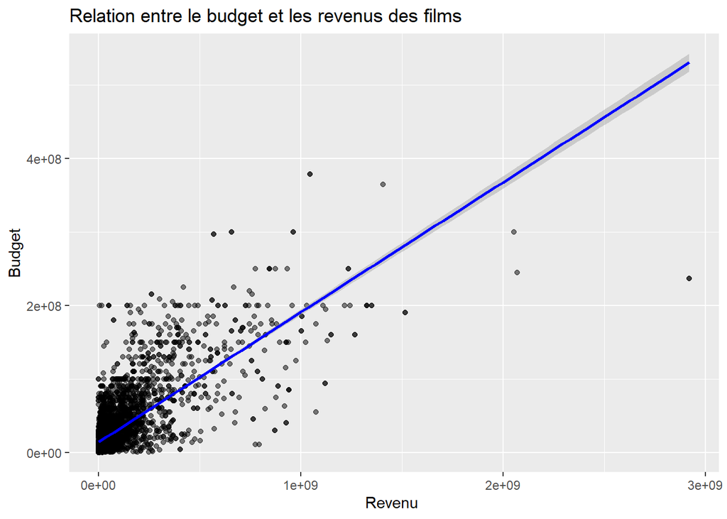

```r
ggplot(clean_movies, aes(x = revenue, y =budget )) +
  geom_point(alpha = 0.5) +
  geom_smooth(method = "lm", color = "blue") +
  labs(title = "Relation entre le budget et les revenus des films", x = "Revenu ", y = "Budget")
```

Ce graphique montre qu’il ya une relation positive entre ces deux variables, cela signifie qu’un grand investissement dans un film génère géneralement un grand revenu mais pas toujours, par exemple ici beaucoups de points sont concentrés dans la partie inferieur du graphe ce qui veut dire que la plus part des films ont un budget et revenu relativement faible . Les points déttachés du lot sont probablement des outliers ou de gros investissements qui ont générés de gros revenus.

**-Visualisation des genres de films populaires pendant les 5 dernière années**

```r
# filtrons les données pour n'avoir que les 5 dernières années
current_year <- as.numeric(format(Sys.Date(), "%Y"))
year_filtered <- clean_movies %>%
  filter(release_year >= (current_year - 5))

# Groupons par genre et année, puis calculons la popularité moyenne
df_summary <- year_filtered %>%
  group_by(genres, release_year) %>%
  summarise(avg_popularity = mean(popularity, na.rm = TRUE))
```

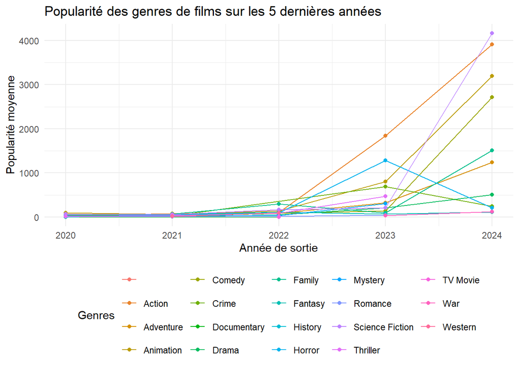

```r
# e graphique
ggplot(df_summary, aes(x = release_year, y = avg_popularity, color = genres)) +
  geom_line() +
  geom_point() +
  theme_minimal() +
  labs(title = "Popularité des genres de films sur les 5 dernières années",
       x = "Année de sortie",
       y = "Popularité moyenne",
       color = "Genres") +
  theme(legend.position = "bottom") +
  scale_x_continuous(breaks = seq(current_year - 5, current_year, by = 1))
```

De ce graphe nous remarquons que la popularité est nulle pour tous les genres jusque vers 2022 et c’est à partir de là que les films d’action ont connu une croissance continue; les films de sciences fiction et d’animation ont connu une forte augmentation de popularité à partir de 2023. D’autres films telques les documentaires, drame, Animation, aventure, sont moyennement croissants.

## III- Modèles de régressions

Régression numérique : Prédiction de la note moyenne (vote_average)

```r
train_movies <- train_movies %>%
  mutate(log_budget = log(budget + 1),
         log_vote_count = log(vote_count + 1))

test_movies <- test_movies %>%
  mutate(log_budget = log(budget + 1),
         log_vote_count = log(vote_count + 1))

lm_vote <- lm(vote_average ~ log_budget + popularity + log_vote_count + release_year, data = train_movies)
summary(lm_vote)
```

```
##
## Call:
## lm(formula = vote_average ~ log_budget + popularity + log_vote_count +
##     release_year, data = train_movies)
##
## Residuals:
##     Min      1Q  Median      3Q     Max
## -6.0199 -0.8968  0.0543  0.9871  4.8888
##
## Coefficients:
##                  Estimate Std. Error t value Pr(>|t|)
## (Intercept)    -8.2922936  0.4861066 -17.059  < 2e-16 ***
## log_budget     -0.0083569  0.0016628  -5.026 5.03e-07 ***
## popularity      0.0002424  0.0001041   2.328   0.0199 *
## log_vote_count  0.1173036  0.0044944  26.100  < 2e-16 ***
## release_year    0.0070116  0.0002435  28.796  < 2e-16 ***
## ---
## Signif. codes:  0 '***' 0.001 '**' 0.01 '*' 0.05 '.' 0.1 ' ' 1
##
## Residual standard error: 1.774 on 79995 degrees of freedom
## Multiple R-squared:  0.02109,    Adjusted R-squared:  0.02104
## F-statistic: 430.8 on 4 and 79995 DF,  p-value: < 2.2e-16
```

Évaluation du modèle :

```r
test_movies <- test_movies %>%
  mutate(release_year = as.numeric(format(as.Date(release_date), "%Y")),
         log_budget = log(budget + 1),
         log_vote_count = log(vote_count + 1))

test_movies <- test_movies %>%
  mutate(pred_vote_avg = predict(lm_vote, newdata = .))

rmse(test_movies, truth = vote_average, estimate = pred_vote_avg)
```

```
## # A tibble: 1 × 3
##   .metric .estimator .estimate
##   <chr>   <chr>          <dbl>
## 1 rmse    standard        1.77
```

```r
movies_r <- clean_movies %>%
  mutate(rentability = ifelse(revenue > budget, 1, 0),
         log_budget = log(budget + 1),
         log_vote_count = log(vote_count + 1))

train_movies <- train_movies %>%
  mutate(rentability = ifelse(revenue > budget, 1, 0),
         log_budget = log(budget + 1),
         log_vote_count = log(vote_count + 1))




glm_rentability <- glm(rentability ~ log_budget + popularity + vote_average + log_vote_count +
                         popularity:vote_average,
                        data = train_movies, family = binomial)

summary(glm_rentability)
```

```
##
## Call:
## glm(formula = rentability ~ log_budget + popularity + vote_average +
##     log_vote_count + popularity:vote_average, family = binomial,
##     data = train_movies)
##
## Coefficients:
##                           Estimate Std. Error z value Pr(>|z|)
## (Intercept)             -6.354e+00  1.081e-01 -58.757   <2e-16 ***
## log_budget               7.168e-02  2.912e-03  24.616   <2e-16 ***
## popularity              -5.678e-05  3.683e-03  -0.015    0.988
## vote_average             1.511e-01  1.622e-02   9.315   <2e-16 ***
## log_vote_count           7.249e-01  1.104e-02  65.639   <2e-16 ***
## popularity:vote_average  6.298e-05  5.227e-04   0.120    0.904
## ---
## Signif. codes:  0 '***' 0.001 '**' 0.01 '*' 0.05 '.' 0.1 ' ' 1
##
## (Dispersion parameter for binomial family taken to be 1)
##
##     Null deviance: 36194  on 79999  degrees of freedom
## Residual deviance: 22119  on 79994  degrees of freedom
## AIC: 22131
##
## Number of Fisher Scoring iterations: 7
```

La régression logistique indique que plusieurs facteurs influencent significativement la rentabilité d’un film. En particulier, le budget (p < 2e-16) et le nombre de votes (p < 2e-16) ainsi que la note moyenne sont des prédicteurs clés. Mais, la popularité seule ainsi que son interaction avec la note moyenne ne semblent pas avoir d’impact significatif Avec une déviance résiduelle de 22 119 et un AIC de 22131, le modèle suggère que les films bénéficiant d’une forte reconnaissance du public, notamment à travers les votes et les notes, ont plus de chances d’être rentables que ceux misant uniquement sur un budget élevé.

```r
test_movies <- test_movies %>%
  mutate(rentability = ifelse(revenue > budget, 1, 0),
         log_budget = log(budget + 1),
         log_vote_count = log(vote_count + 1))

test_movies <- test_movies %>%
  mutate(prob_rentable = predict(glm_rentability, newdata = ., type = "response"),
         pred_rentable = ifelse(prob_rentable > 0.5, 1, 0))

test_movies <- test_movies %>%
  mutate(
    rentability = as.factor(rentability),
    pred_rentable = as.factor(pred_rentable)
  )
conf_mat(test_movies, truth = rentability, estimate = pred_rentable)
```

```
##           Truth
## Prediction     0     1
##          0 18629   679
##          1   206   486
```

```r
accuracy(test_movies, truth = rentability, estimate = pred_rentable)
```

```
## # A tibble: 1 × 3
##   .metric  .estimator .estimate
##   <chr>    <chr>          <dbl>
## 1 accuracy binary         0.956
```

Courbe ROC pour évaluer la performance de notre modèle:

```r
library(pROC)
```

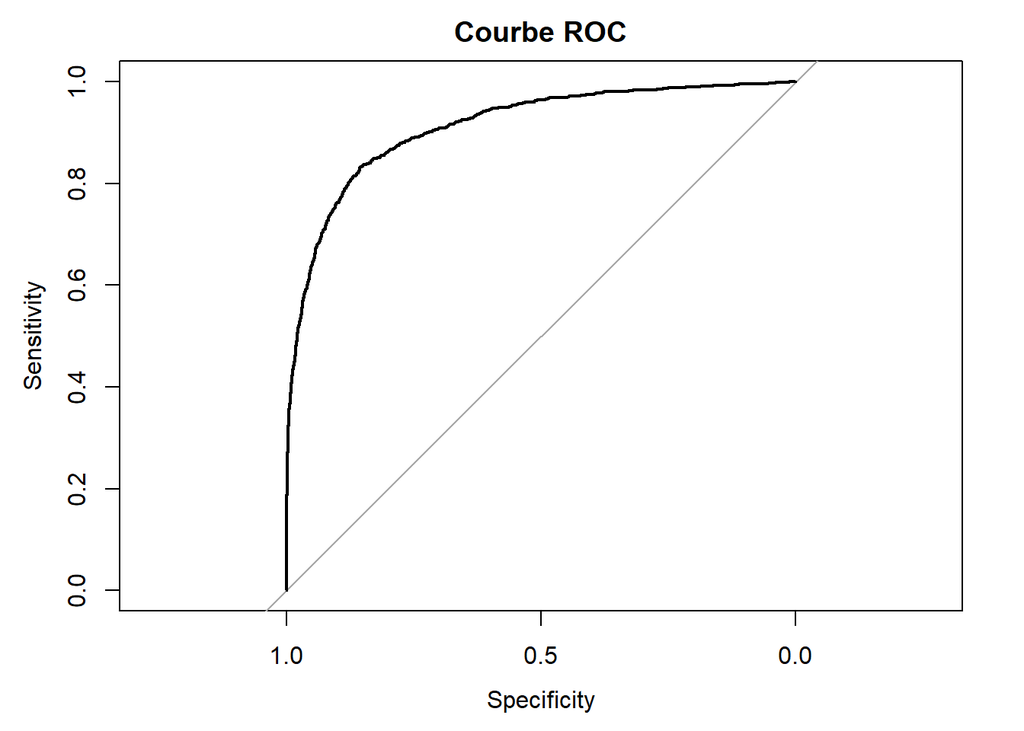

```r
roc_curve <- roc(test_movies$rentability, test_movies$prob_rentable)
plot(roc_curve, main = "Courbe ROC")
```

```r
auc_value <- auc(roc_curve)
print(paste("AUC:", auc_value))
```

```
## [1] "AUC: 0.912091861672008"
```